# 208275792_209014448

Jonathan Wiesenfeld & Rom Meltzer

2023-06-04

## Prior Contents

Load Relevant libraries

```r
library(tidyverse) # This includes dplyr, stringr, ggplot2, ..
library(data.table)
library(rworldmap) # world map
library(ggthemes)
library(reshape2) # melt: change data-frame format long/wide
library(e1071) # skewness and kurtosis
library(rvest)
library(dplyr)
library(corrplot)
library(car) #From moodle forum
```

## Q1: Loading data and basic processing:

Loading the contents of “The Economist Democracy Index”; “List by Country”, “List by Region”, and “Components”. Use html_table to extract the individual tables from the all.tables object.

```r
url = 'https://en.wikipedia.org/wiki/The_Economist_Democracy_Index'
source = read_html(url)
all.tables = html_nodes(source, "table")
list.by.region <- source %>%
  html_nodes(xpath = "/html/body/div[2]/div/div[3]/main/div[3]/div[3]/div[1]/table[3]") %>%
  html_table(fill =TRUE)
list.by.region <- as.data.frame(list.by.region[[1]])
list.by.country <- source %>%
  html_nodes(xpath = '//*[@id="mw-content-text"]/div[1]/table[5]') %>%
  html_table(fill = TRUE)
list.by.country <- as.data.frame(list.by.country[[1]])
components <- source %>%
  html_nodes(xpath = '//*[@id="mw-content-text"]/div[1]/table[6]') %>%
  html_table(fill=TRUE)
components <- as.data.frame(components[[1]])
components <- components[c(-1,-2,-27,-76,-113),-2]
head(list.by.region, 5)
```

```
##                            Region Countries 2022 2021 2020 2019 2018 2017 2016
## 1                   North America          2 8.37 8.36 8.58 8.59 8.56 8.56 8.56
## 2                  Western Europe         21 8.36 8.23 8.29 8.35 8.35 8.38 8.40
## 3 Latin America and the Caribbean         24 5.79 5.83 6.09 6.13 6.24 6.26 6.33
## 4            Asia and Australasia         28 5.46 5.46 5.62 5.67 5.67 5.63 5.74
## 5      Central and Eastern Europe         28 5.39 5.36 5.36 5.42 5.42 5.40 5.43
##   2015 2014 2013 2012 2011 2010 2008 2006
## 1 8.56 8.59 8.59 8.59 8.59 8.63 8.64 8.64
## 2 8.42 8.41 8.41 8.44 8.40 8.45 8.61 8.60
## 3 6.37 6.36 6.38 6.36 6.35 6.37 6.43 6.37
## 4 5.74 5.70 5.61 5.56 5.51 5.53 5.58 5.44
## 5 5.55 5.58 5.53 5.51 5.50 5.55 5.67 5.76
```

```r
head(list.by.country, 5)
```

```
##           Region 2022 rank       Country      Regime type 2022 2021 2020 2019
## 1  North America        12        Canada   Full democracy 8.88 8.87 9.24 9.22
## 2  North America        30 United States Flawed democracy 7.85 7.85 7.92 7.96
## 3 Western Europe        20       Austria   Full democracy 8.20 8.07 8.16 8.29
## 4 Western Europe        36       Belgium Flawed democracy 7.64 7.51 7.51 7.64
## 5 Western Europe        37        Cyprus Flawed democracy 7.38 7.43 7.56 7.59
##   2018 2017 2016 2015 2014 2013 2012 2011 2010 2008 2006
## 1 9.15 9.15 9.15 9.08 9.08 9.08 9.08 9.08 9.08 9.07 9.07
## 2 7.96 7.98 7.98 8.05 8.11 8.11 8.11 8.11 8.18 8.22 8.22
## 3 8.29 8.42 8.41 8.54 8.54 8.48 8.62 8.49 8.49 8.49 8.69
## 4 7.78 7.78 7.77 7.93 7.93 8.05 8.05 8.05 8.05 8.16 8.15
## 5 7.59 7.59 7.65 7.53 7.40 7.29 7.29 7.29 7.29 7.70 7.60
```

```r
head(components, 5)
```

```
##   Rank     Country    Regime type Overall score Δ Score
## 3    1      Norway Full democracy          9.81    0.06
## 4    2 New Zealand Full democracy          9.61    0.14
## 5    3     Iceland Full democracy          9.52    0.34
## 6    4      Sweden Full democracy          9.39    0.13
## 7    5     Finland Full democracy          9.29    0.02
##   Electoral processand pluralism Functioningof government
## 3                             10.00                       9.64
## 4                             10.00                       9.29
## 5                             10.00                       9.64
## 6                              9.58                       9.64
## 7                             10.00                       9.64
##   Politicalparticipation Politicalculture Civilliberties
## 3                    10.00              10.00            9.41
## 4                    10.00               8.75           10.00
## 5                     8.89               9.38            9.71
## 6                     8.33              10.00            9.41
## 7                     8.33               8.75            9.71
```

## Q1b

Displaying the 5 top and bottom countries based on democracy index in 2022.

```r
bottom_five <- list.by.country %>%
  arrange(desc(`2022 rank`)) %>%
  select(`Country`, `2022 rank` ) %>%
  head(5)

top_five <- list.by.country %>%
  arrange(`2022 rank`) %>%
  select(`Country`, `2022 rank`) %>%
  head(5)
top_five
```

```
##       Country 2022 rank
## 1      Norway         1
## 2 New Zealand         2
## 3     Iceland         3
## 4      Sweden         4
## 5     Finland         5
```

```r
bottom_five
```

```
##                    Country 2022 rank
## 1              Afghanistan       167
## 2                  Myanmar       166
## 3              North Korea       165
## 4 Central African Republic       164
## 5                    Syria       163
```

Repeat with average score between 2006 and 2022.

```r
avg.list<-rowMeans(list.by.country[5:length(list.by.country)])
avg.list.withcountry<-data.frame(Country=list.by.country$Country,avg.list)
sorted.alw <- avg.list.withcountry[order(avg.list.withcountry$avg.list, decreasing = TRUE), ]
avg_top_5 <- sorted.alw[1:5, ]
avg_bottom_5 <- sorted.alw[(nrow(sorted.alw)-4):nrow(sorted.alw), ]
avg_top_5
```

```
##        Country avg.list
## 17      Norway 9.830667
## 11     Iceland 9.562000
## 20      Sweden 9.524667
## 6      Denmark 9.305333
## 92 New Zealand 9.268667
```

```r
avg_bottom_5
```

```
##                      Country avg.list
## 49              Turkmenistan 1.741333
## 120                    Syria 1.700667
## 131 Central African Republic 1.581333
## 132                     Chad 1.569333
## 93               North Korea 1.062000
```

## Q2: Plotting distributions of groups of countries:

We created boxplot for each region based on the distribution of *democracy index*. Calculated the outliers based on boxplot.stats; Israel and Turkey.

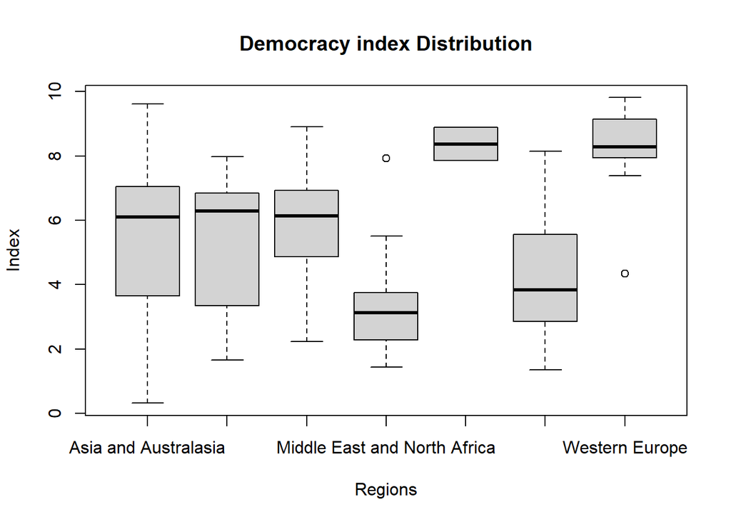

```r
boxplot(list.by.country$"2022" ~ list.by.country$Region,xlab="Regions",ylab="Index",main = "Democracy index Distribution")
```

```r
regions<- list.by.country$Region %>% unique()

combined_list <- vector("list", length(regions))
for (i in 1:length(regions)) {
  region <- regions[i]
  data_vec <- list.by.country$"2022"[which(list.by.country$Region == region)]
  combined_list[[i]] <- data_vec
}
for(i in 1:length(regions)){
  if(boxplot.stats(combined_list[[i]])[4]!="numeric(0)"){
    for(j in boxplot.stats(combined_list[[i]])[4]){
      print(list.by.country$Country[which(list.by.country$"2022"==j)])
    }
  }
}
```

```
## [1] "Turkey"
## [1] "Israel"
```

## Q2b

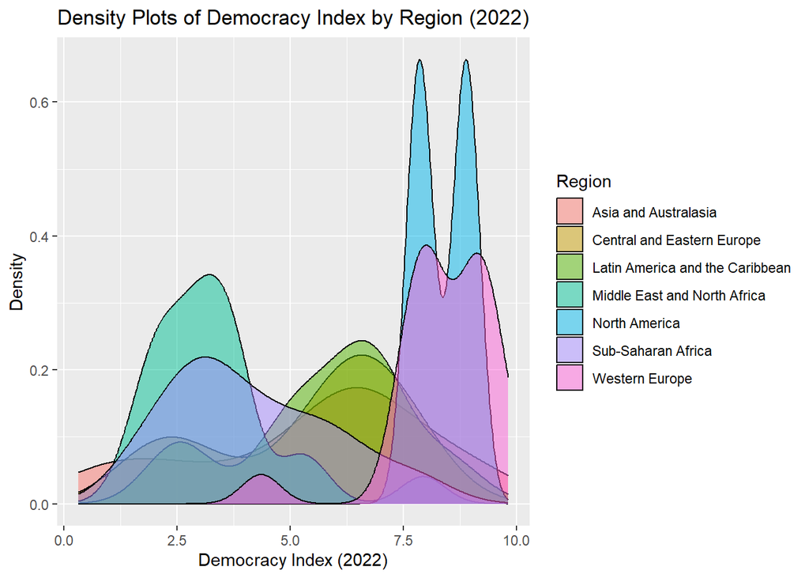

```r
ggplot(list.by.country, aes(x = `2022`, fill = Region)) +
  geom_density(alpha = 0.5) +
  labs(x = "Democracy Index (2022)", y = "Density") +
  ggtitle("Density Plots of Democracy Index by Region (2022)")
```

```r
summary_stats <- list.by.country %>%
  group_by(Region) %>%
  summarise(
    Mean = mean(`2022`),
    Variance = var(`2022`),
    Skewness = skewness(`2022`),
    Kurtosis = kurtosis(`2022`)
  )

print(summary_stats)
```

```
## # A tibble: 7 × 5
##   Region                           Mean Variance Skewness Kurtosis
##   <chr>                           <dbl>    <dbl>    <dbl>    <dbl>
## 1 Asia and Australasia             5.46    6.68    -0.501   -0.841
## 2 Central and Eastern Europe       5.39    4.23    -0.615   -1.15
## 3 Latin America and the Caribbean  5.79    3.40    -0.473   -0.688
## 4 Middle East and North Africa     3.34    2.22     1.43     2.10
## 5 North America                    8.36    0.530    0       -2.75
## 6 Sub-Saharan Africa               4.14    3.18     0.489   -0.733
## 7 Western Europe                   8.36    1.36    -1.73     3.93
```

Mean: The mean represents the average value of the democracy index for each region in 2022. It provides a measure of central tendency. For example, in the “North America” region, the mean democracy index is 8.36, indicating that, on average, countries in this region tend to have a higher democracy index compared to other regions.

Variance: The variance measures the spread or dispersion of the democracy index values within each region. A lower variance indicates that the values are clustered closer to the mean, while a higher variance suggests greater variability. For instance, the “North America” region has a variance of 0.530, indicating relatively low variability in the democracy index values compared to other regions.

Skewness: Skewness quantifies the asymmetry of the distribution. A skewness value close to 0 suggests a symmetric distribution, while positive or negative values indicate right-skewed or left-skewed distributions, respectively. For example, the “Middle East and North Africa” region has a positive skewness of 1.43, indicating that the democracy index values are skewed towards lower values.

Kurtosis: Kurtosis measures the shape of the distribution and describes the presence of heavy tails or outliers compared to a normal distribution. Positive kurtosis indicates a distribution with heavier tails and potentially more outliers, while negative kurtosis suggests a distribution with lighter tails. In the table, the “Western Europe” region has a high positive kurtosis of 3.93, indicating a distribution with heavy tails and potentially more extreme values (outliers).

## Q3: Comparing countries and showing trends in democracy index:

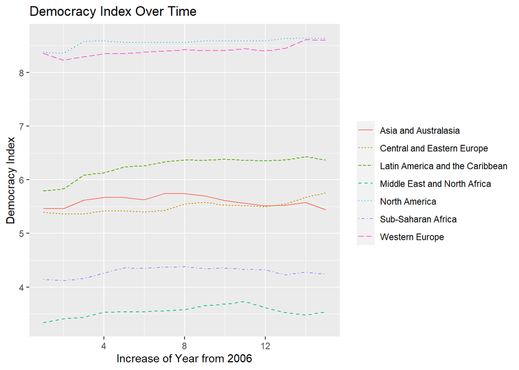

```r
#A function for listbycountry
plot_democracy_index_country <- function(data, names) {
  subset_data <- data[data$Country %in% names, ]
  grouping_column <- "Country"
  subset_data_long <- reshape2::melt(subset_data, id.vars = c("Country", "Region", "Regime type", "2022 rank"), variable.name = "Year", value.name = "DemocracyIndex")
  subset_data_long$Year <- as.integer(subset_data_long$Year)
  ggplot(subset_data_long, aes(x = Year, y = DemocracyIndex, color = get(grouping_column))) +
    geom_line() +
    labs(x = "Increase of Year from 2006", y = "Democracy Index", color = grouping_column, linetype = grouping_column) +
    ggtitle("Democracy Index Over Time") +
    theme(legend.title = element_blank())}

#A function for listbyregion

plot_democracy_index_region <- function(data, names) {
  subset_data <- data[data$Region %in% names, ]
  grouping_column <- "Region"
  subset_data <- subset_data[, c("Region", "2022", "2021", "2020", "2019", "2018", "2017", "2016", "2015", "2014", "2013", "2012", "2011", "2010", "2008", "2006")]
  subset_data_long <- reshape2::melt(subset_data, id.vars = "Region", variable.name = "Year", value.name = "DemocracyIndex")
  subset_data_long$Year <- as.numeric(subset_data_long$Year)
  ggplot(subset_data_long, aes(x = Year, y = DemocracyIndex, color = get(grouping_column), linetype = get(grouping_column))) +
    geom_line() +
    labs(x = "Increase of Year from 2006", y = "Democracy Index", color = grouping_column, linetype = grouping_column) +
    ggtitle("Democracy Index Over Time") +
    theme(legend.title = element_blank())
}
plot_democracy_index_region(list.by.region,c("North America","Western Europe","Latin America and the Caribbean","Asia and Australasia","Central and Eastern Europe","Sub-Saharan Africa","Middle East and North Africa" ))
```

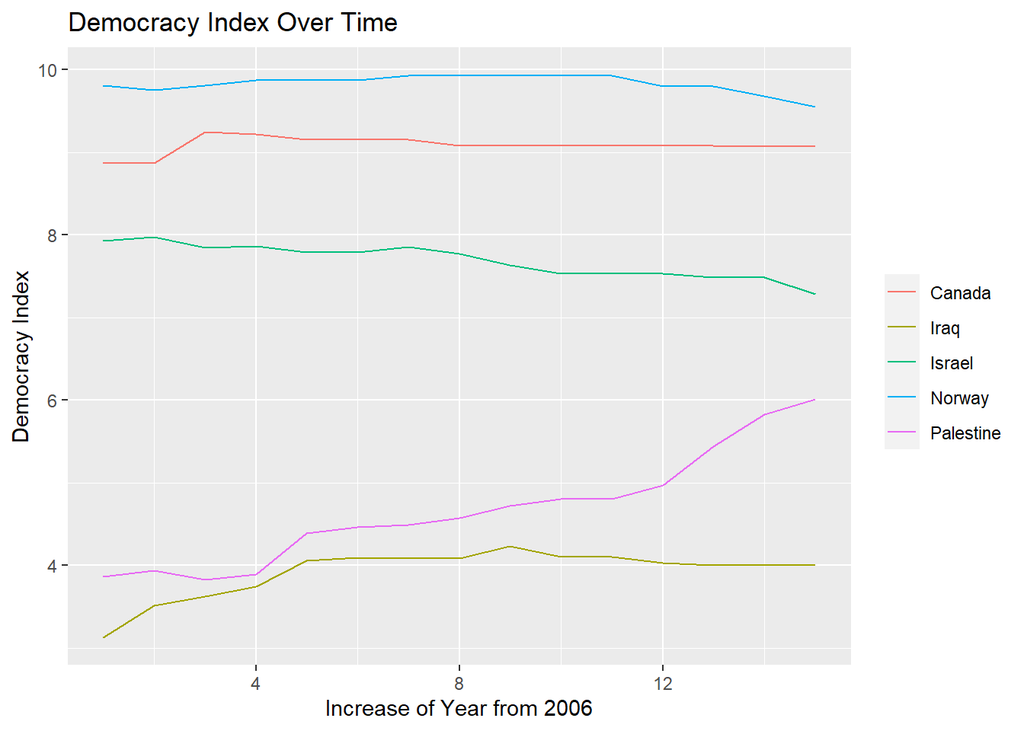

```r
plot_democracy_index_country(list.by.country,c("Canada","Israel","Iraq","Palestine","Norway"))
```

## Q3b The code creates eight separate clusters of countries based on changes in the democracy index between 2006 and 2022. Each cluster is defined based on specific conditions such as the magnitude and direction of change. The resulting clusters are then used to create separate data frames for each cluster. The plot_democracy_index_country function is used to plot the democracy index over time for each cluster of countries.

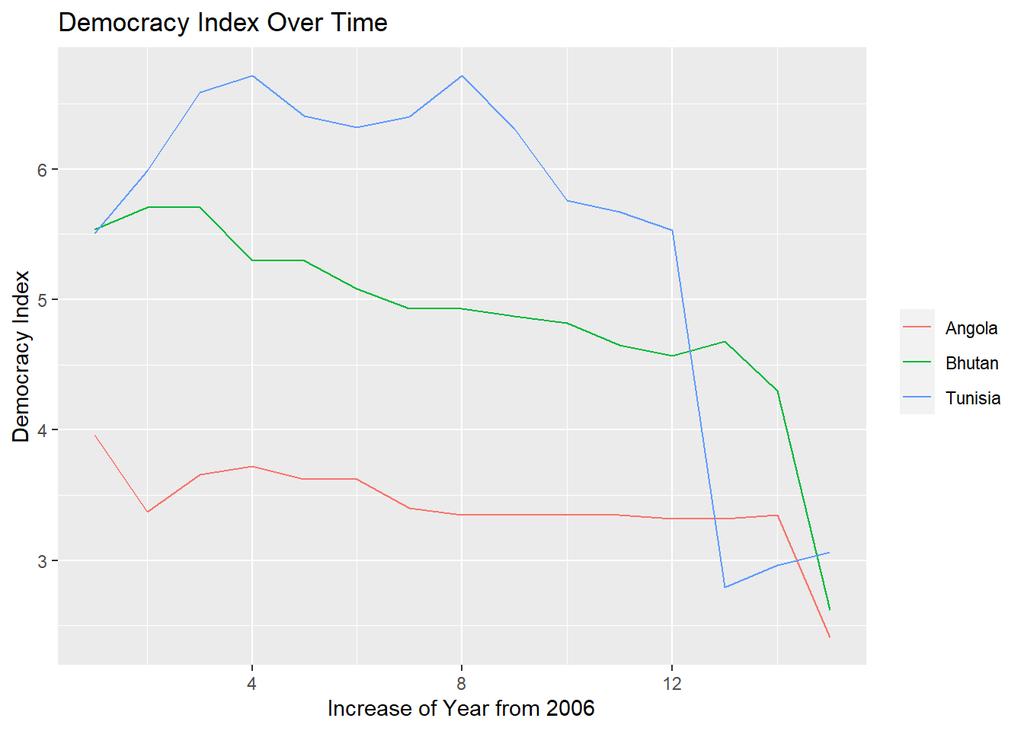

```r
list.by.country$Change <- list.by.country$`2022` - list.by.country$`2006`
cluster1 <- list.by.country[list.by.country$Change >= 1.5, ]
cluster2 <- list.by.country[list.by.country$Change <= -1.5, ]
cluster3 <- list.by.country[list.by.country$Change >= 0.75 & list.by.country$Change <= 1.5, ]
cluster4 <- list.by.country[list.by.country$Change <= -0.75 & list.by.country$Change >= -1.5, ]
cluster5 <- filter(list.by.country,list.by.country$"2006" - apply(list.by.country[,5:19],1,min)>=0.75 & list.by.country$"2022"- apply(list.by.country[,5:19],1,min)>=0.75)
cluster6 <- filter(list.by.country,list.by.country$"2006" - apply(list.by.country[,5:19],1,max)<= -0.75 & list.by.country$"2022"- apply(list.by.country[,5:19],1,max)<= -0.75)
cluster7 <- filter(list.by.country, (apply(list.by.country[, 5:19],1,max) - apply(list.by.country[, 5:19], 1, min)) < 0.5)
lis<-c(cluster1$Country, cluster2$Country, cluster3$Country, cluster4$Country, cluster5$Country,cluster6$Country,cluster7$Country)
cluster8 <- list.by.country[!list.by.country$Country %in% lis,]
#clean the data and plot using the function
cluster1_data <- subset(cluster1, select = -c(Change))
cluster2_data <- subset(cluster2, select = -c(Change))
cluster3_data <- subset(cluster3, select = -c(Change))
cluster4_data <- subset(cluster4, select = -c(Change))
cluster5_data <- subset(cluster5, select = -c(Change))
cluster6_data <- subset(cluster6, select = -c(Change))
cluster7_data <- subset(cluster7, select = -c(Change))
cluster8_data <- subset(cluster8, select = -c(Change))

plot_democracy_index_country(cluster1_data, cluster1$Country)
```

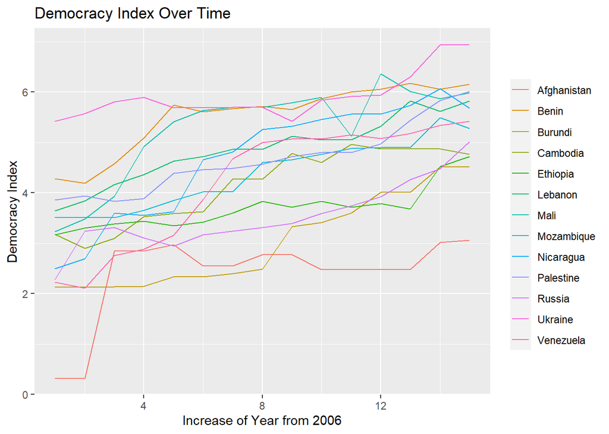

```r
plot_democracy_index_country(cluster2_data, cluster2$Country)
```

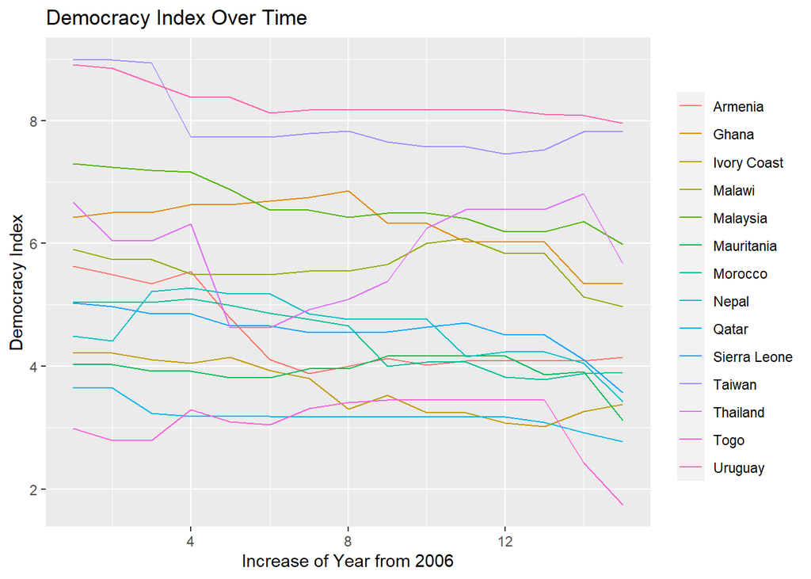

```r
plot_democracy_index_country(cluster3_data, cluster3$Country)
```

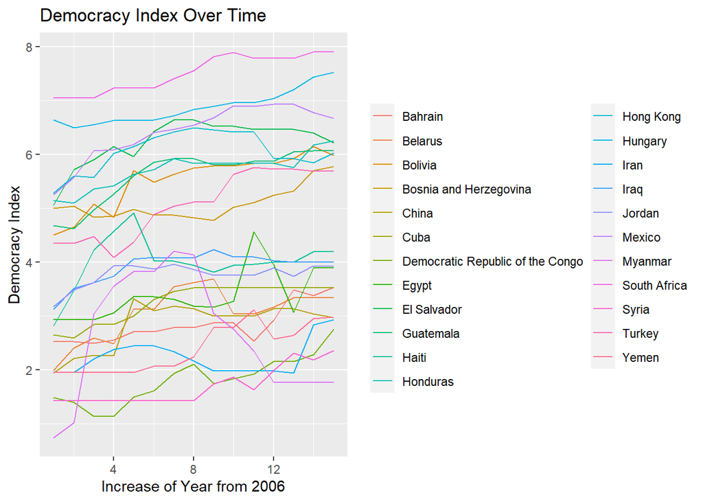

```r
plot_democracy_index_country(cluster4_data, cluster4$Country)
```

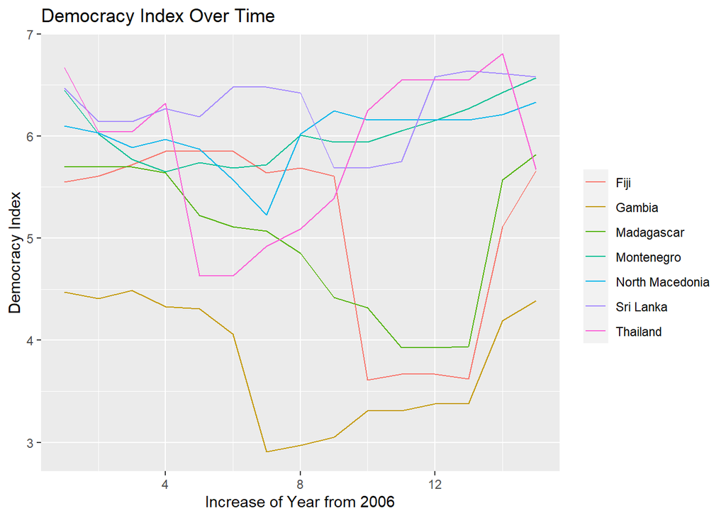

```r
plot_democracy_index_country(cluster5_data, cluster5$Country)
```

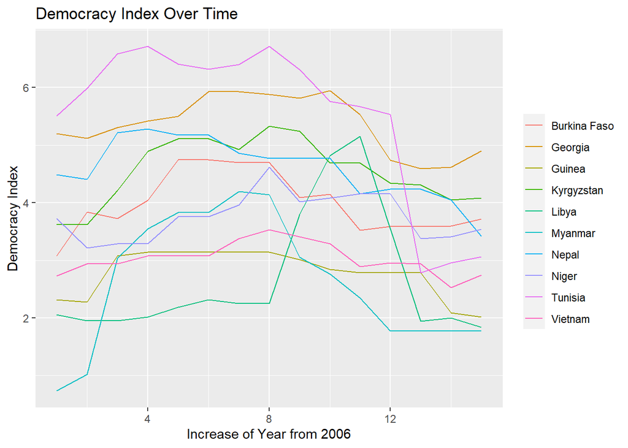

```r
plot_democracy_index_country(cluster6_data, cluster6$Country)
```

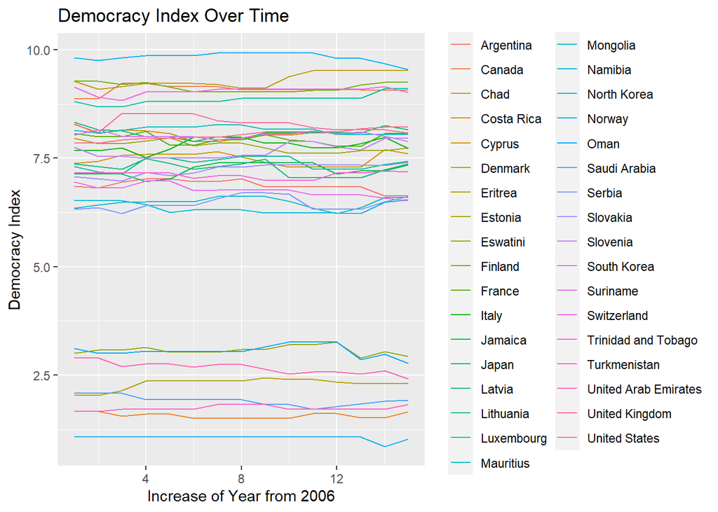

```r
plot_democracy_index_country(cluster7_data, cluster7$Country)
```

[figure not shown]

```r
plot_democracy_index_country(cluster8_data, cluster8$Country)
```

## Q4: Change in category

```r
#helper function to determine type of regime for each country.
whichDemocracy<-function(num){
  ifelse(num>8 & num <=10,"Full democracy",
         ifelse(num>6 & num<=8, "Flawed democracy",
                ifelse(num>4 & num<=6,"Hybrid Regime","Authoritarian")))

}
data_2006 <- list.by.country$"2006"
data_2022 <- list.by.country$"2022"

empirical_changes<-function(old,new){
  regime.type<-c("Full democracy","Flawed democracy","Hybrid Regime","Authoritarian")
  result<-data.frame(matrix(0,nrow=4,ncol = 4,dimnames = c(regime.type %>% list(),regime.type %>% list())))
  for(i in 1:length(regime.type)){
    for(j in 1:length(regime.type)){
      to<-list.by.country$Country[which(whichDemocracy(data_2006)==regime.type[i])]
      from<-list.by.country$Country[which(whichDemocracy(data_2022)==regime.type[j])]
      val<-length(to[to%in%from])/length(to)
      result[i,j]<-val

    }
  }
  return(result)
}

empirical_changes(data_2006,data_2022)
```

```
##                  Full.democracy Flawed.democracy Hybrid.Regime Authoritarian
## Full democracy        0.7692308        0.2307692     0.0000000    0.00000000
## Flawed democracy      0.0754717        0.6981132     0.2075472    0.01886792
## Hybrid Regime         0.0000000        0.1515152     0.4848485    0.36363636
## Authoritarian         0.0000000        0.0000000     0.1636364    0.83636364
```

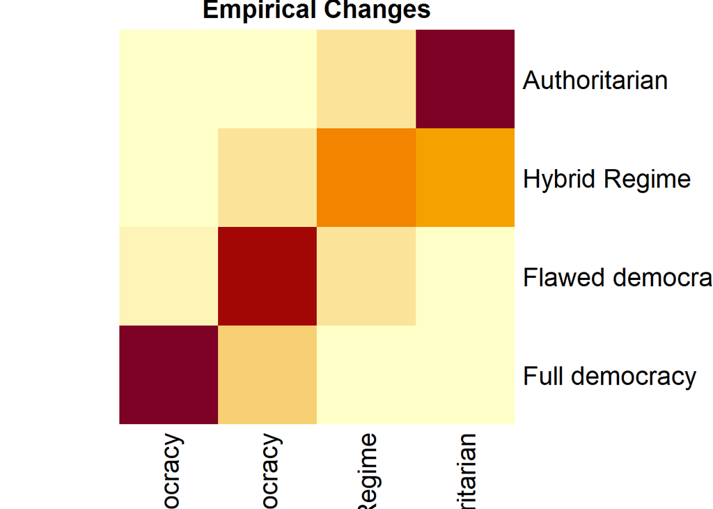

```r
heatmap(empirical_changes(data_2006,data_2022)%>%as.matrix(),
        Rowv = NA,      # Disable row clustering
        Colv = NA,      # Disable column clustering
        scale = "none", # Do not scale the values
        main = "Empirical Changes",
        colnames = names,
        rownames = names)
```

## Q5: Joining data from additional tables

We added the new sources, and cleaned the data to match our specifications. For example, we change the column names for all tables that represent country names, to be only *“Country”*.

```r
url = "https://en.wikipedia.org/wiki/List_of_countries_by_GDP_(PPP)_per_capita"
source = read_html(url)
all.tables = html_nodes(source, "table")
gdp.countries <- source %>%
  html_nodes(xpath = '//*[@id="mw-content-text"]/div[1]/table[1]') %>%
  html_table(fill =TRUE)
gdp.countries <- as.data.frame(gdp.countries[[1]])
colnames(gdp.countries)[1] <- "Country"
gdp.countries.clean<-gdp.countries[,c('Country',"CIA[8][9][10]")]
#INCARNATION
url = "https://en.wikipedia.org/wiki/List_of_countries_by_incarceration_rate"
source = read_html(url)
all.tables = html_nodes(source, "table")
incarnation.rates <- source %>%
  html_nodes(xpath = '//*[@id="mw-content-text"]/div[1]/table[2]') %>%
  html_table(fill =TRUE)
incarnation.rates <- as.data.frame(incarnation.rates[[1]])
#AREA

url = "https://en.wikipedia.org/wiki/List_of_countries_and_dependencies_by_area"
source = read_html(url)
all.tables = html_nodes(source, "table")
area <- source %>%
  html_nodes(xpath = '//*[@id="mw-content-text"]/div[1]/table[2]') %>%
  html_table(fill =TRUE)
area <- as.data.frame(area[[1]])

#POPULATION SIZE
url = "https://en.wikipedia.org/wiki/List_of_countries_and_dependencies_by_population"
source = read_html(url)
all.tables = html_nodes(source, "table")
population <- source %>%
  html_nodes(xpath = '//*[@id="mw-content-text"]/div[1]/table[2]') %>%
  html_table(fill =TRUE)
population <- as.data.frame(population)
#Change the name of the column country
colnames(area)[2] = "Country"
colnames(population)[2] = "Country"
colnames(incarnation.rates)[1] = "Country"
colnames(gdp.countries)[1] = "Country"
#clean the names
incarnation.rates$Country= gsub("\\*", "", incarnation.rates$Country)
incarnation.rates$Country= gsub("\\ ","", incarnation.rates$Country)
incarnation.rates$Country= gsub("\\s", "", incarnation.rates$Country)
incarnation.rates$Country = gsub("\\[Note\\]", "", incarnation.rates$Country)
gdp.countries$Country= gsub("\\*", "", gdp.countries$Country)
gdp.countries$Country= gsub("\\ ","", gdp.countries$Country)
gdp.countries$Country= gsub("\\s","", gdp.countries$Country)
area$Country= gsub("\\ ", "", area$Country)
area$Country= gsub("\\(.*\\)", "", area$Country)
area$Country= gsub("\\s", "", area$Country)
population$Country= gsub("\\ ", "", population$Country)
population$Country= gsub("\\(.*\\)", "", population$Country)
population$Country= gsub("\\s", "", population$Country)
list.by.country$Country=gsub("\\ ", "", list.by.country$Country)
list.by.country$Country= gsub("\\(.*\\)", "", list.by.country$Country)


combined.table.GI=merge(gdp.countries,incarnation.rates)
combined.table.GIA=merge(combined.table.GI,area)
combined.table.GIAP=merge(combined.table.GIA,population,by="Country")
combined.table.GIAPL=merge(combined.table.GIAP,list.by.country,by="Country")

head(combined.table.GIAPL,5)
```

```
##       Country UN Region IMF[5][6] IMF[5][6] World Bank[7] World Bank[7]
## 1 Afghanistan      Asia     2,456      2020         1,666          2021
## 2     Albania    Europe    19,029      2023        15,709          2021
## 3     Algeria    Africa    13,507      2023        12,128          2021
## 4      Angola    Africa     7,222      2023         6,491          2021
## 5   Argentina  Americas    27,261      2023        23,650          2021
##   CIA[8][9][10] CIA[8][9][10] Region.x Count[2] Rate per 100,000 [3]
## 1         1,500          2021     Asia   28,240                   77
## 2        14,500          2021   Europe    5,112                  183
## 3        11,000          2021   Africa   94,749                  217
## 4         5,900          2021   Africa   24,966                   79
## 5        21,500          2021 Americas  114,074                  249
##   Male (%)[a] Female (%)[4] National (%)[b] Foreign (%)[5] Occupancy (%)[6]
## 1        97.4           2.6            99.1            0.9            179.9
## 2        98.0           2.0            98.1            1.9             84.7
```

[output cut: 33 more lines]

## Q5b

Here we try to fit a regression line, firstly with “GDP per capita” (=“CIA_reported”) as the response, and lastly with “incarnation rates” as the response.

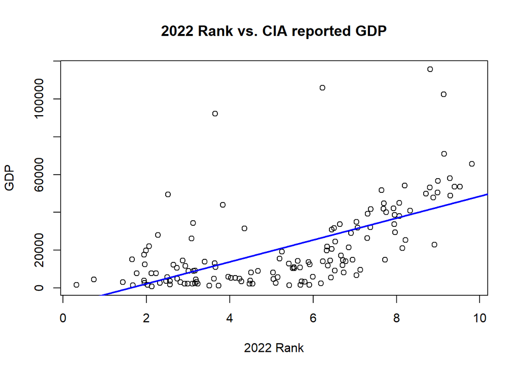

```r
CIA_reported <- as.numeric(gsub(",","",combined.table.GIAPL$`CIA[8][9][10]`))
incar_rate <- as.numeric(combined.table.GIAPL$`Rate per 100,000 [3]`)
data_2022 <- as.numeric(combined.table.GIAPL$`2022`)


gdp.by.rank<-lm(CIA_reported~data_2022)
plot(data_2022,y = CIA_reported,xlab="2022 Rank",ylab = "GDP",main = "2022 Rank vs. CIA reported GDP")
abline(gdp.by.rank, col="Blue", lwd = 2)
```

[figure not shown]

```r
gdp.by.incar<-lm(incar_rate~data_2022)
plot(x=data_2022,incar_rate,xlab="2022 rank",ylab = "Incarnation rate",main = "Incarnation Rate vs. CIA reported GDP")
abline(gdp.by.incar, col="Blue", lwd = 2)
```

## Q6: Empirical Cumulative Distribution Function (CDF)

The code computes and plots the empirical cumulative distribution function (CDF) of the GDP (PPP) per capita for randomly selected countries. It first removes non-numeric characters from the CIA[8][9][10] column, converts it to numeric, and then uses the ecdf function to compute the empirical CDF. The resulting CDF is then plotted.

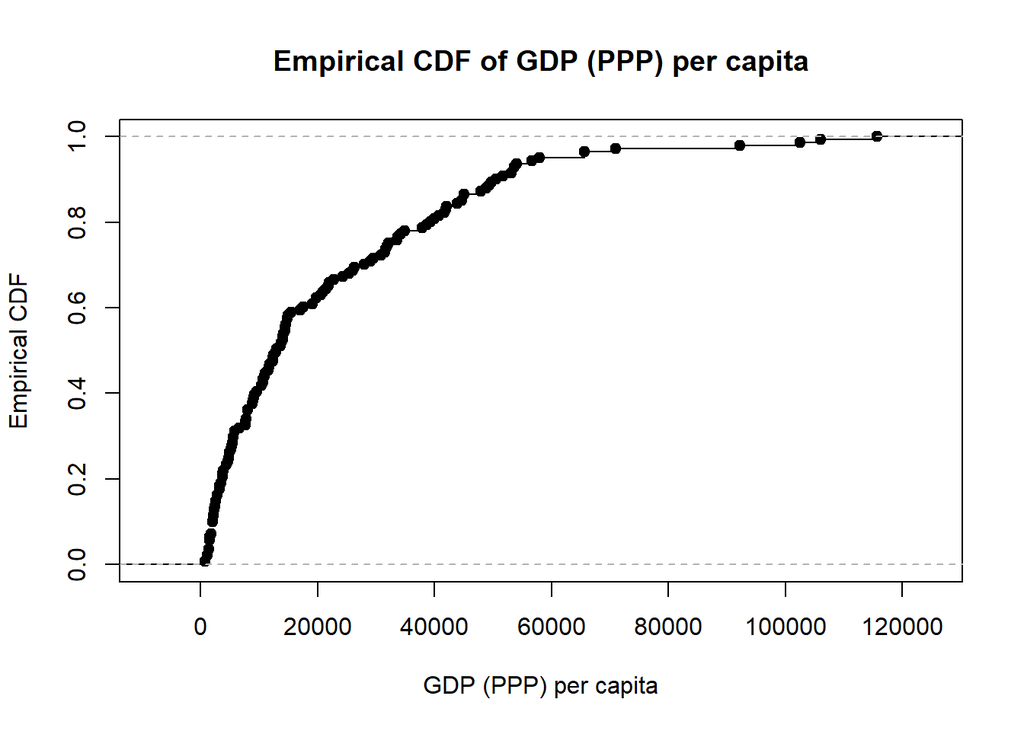

```r
# Compute the empirical CDF
combined.table.GIAPL$`CIA[8][9][10]`<-as.numeric(gsub("[^0-9.]","",combined.table.GIAPL$`CIA[8][9][10]`))
gdp=ecdf(combined.table.GIAPL$`CIA[8][9][10]`)
plot(gdp, main = "Empirical CDF of GDP (PPP) per capita", xlab = "GDP (PPP) per capita", ylab = "Empirical CDF")
```

## Q6b The code computes and plots the empirical CDF of the GDP per capita for randomly selected individuals in the world. It calculates the GDP per capita by dividing the population size by the corresponding GDP values, sorts the values, and computes the empirical probabilities. The resulting CDF is plotted to show the cumulative probability distribution.

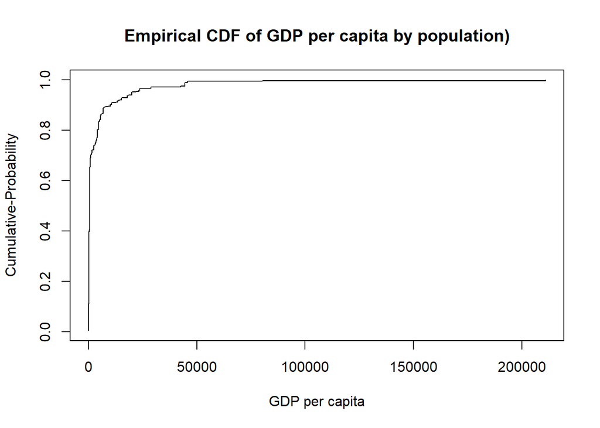

```r
combined.table.GIAPL$Population <- as.numeric(gsub("[^0-9.]","",combined.table.GIAPL$Population))
combined.table.GIAPL$`CIA[8][9][10]`<-as.numeric(gsub("[^0-9.]","",combined.table.GIAPL$`CIA[8][9][10]`))
gdp_per_capita <-combined.table.GIAPL$Population / combined.table.GIAPL$`CIA[8][9][10]`
gdp_per_capita.sort=sort(gdp_per_capita)
empirical_probs <- cumsum(combined.table.GIAPL$Population) / sum(combined.table.GIAPL$Population)
plot(gdp_per_capita.sort, empirical_probs, type = "s", main = "Empirical CDF of GDP per capita by population)",
     xlab = "GDP per capita", ylab = "Cumulative-Probability")
```

## Q6c The code computes and plots the empirical CDF of the GDP per capita for randomly selected individuals based on their location within the land area on Earth. It removes non-numeric characters from the Landin km2 (mi2) column, converts it to numeric, and filters out the corresponding GDP per capita values based on valid indices. It then calculates the GDP per capita per unit of land area, computes the weighted empirical CDF using land area as weights, and plots the resulting CDF.

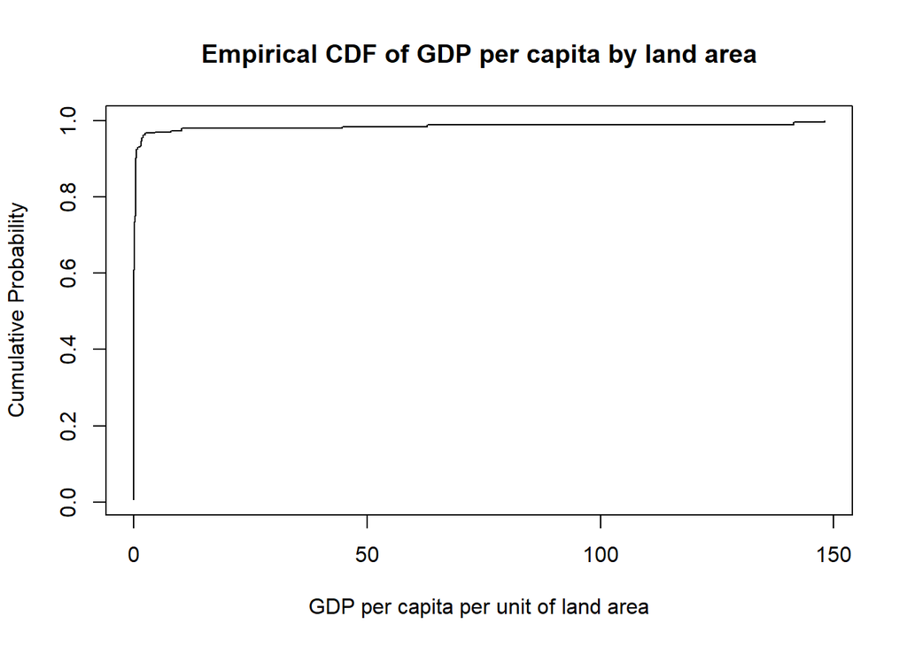

```r
#remove number in parentheses
converttochar<-as.character(combined.table.GIAPL$`Landin km2 (mi2)`)
cleaned_values <- gsub("\\s*\\([^)]+\\)|,", "", converttochar)
land_areakm2 <- as.numeric(cleaned_values)
#check for index that are not NA and match with the other vector
valid_indices <- !is.na(land_areakm2)
land_areakm2 <- land_areakm2[valid_indices]
# Filter the corresponding values from CIA[8][9][10] based on the same valid indices
gdp_per_capita <- as.numeric(gsub("[^0-9.]","",combined.table.GIAPL$`CIA[8][9][10]`))
gdp_per_capita <- gdp_per_capita[valid_indices]
# Calculate GDP per capita per unit of land area
gdp_per_capita_land <- gdp_per_capita / land_areakm2
# Compute weighted empirical CDF using land area as weights
empirical_probs_land <- cumsum(land_areakm2) / sum(land_areakm2)
# Plot the empirical CDF
plot(sort(gdp_per_capita_land), empirical_probs_land, type = "s",
     main = "Empirical CDF of GDP per capita by land area",
     xlab = "GDP per capita per unit of land area", ylab = "Cumulative Probability")
```

## Q7: Displaying data on the world map

```
## 165 codes from your data successfully matched countries in the map
## 2 codes from your data failed to match with a country code in the map
## 78 codes from the map weren't represented in your data
```

```
## 165 codes from your data successfully matched countries in the map
## 2 codes from your data failed to match with a country code in the map
## 78 codes from the map weren't represented in your data
```

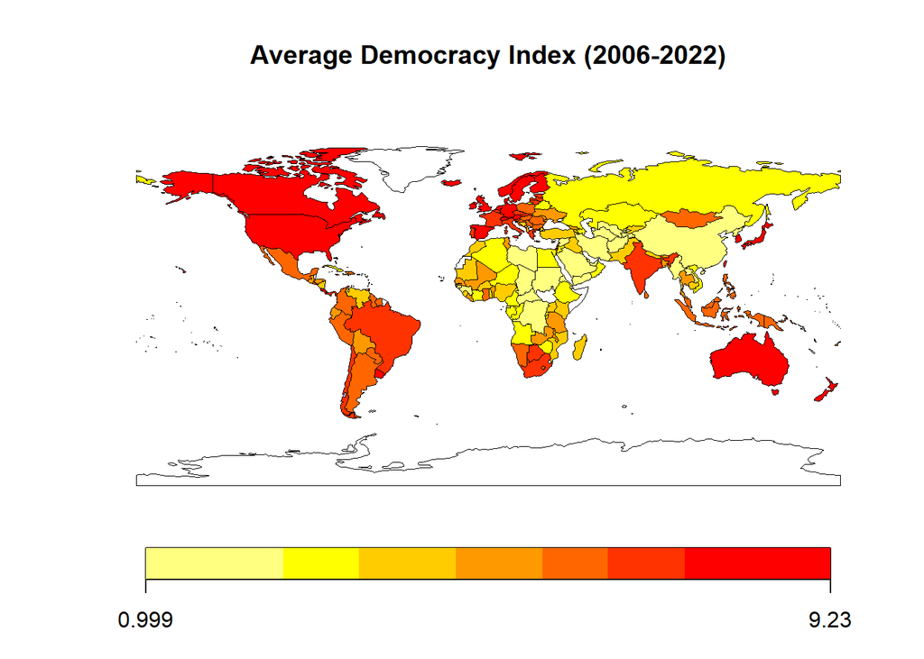

Next, we plot the *changes* in the democracy index between 2006 and 2022.

```r
#Changes in Index

change_in_years <- list.by.country$`2022` - list.by.country$`2006`
changes_map_list=bind_cols(list.by.country$Country,change_in_years)
```

```r
colnames(changes_map_list)[colnames(changes_map_list) == "...1"] <- "Country"
colnames(changes_map_list)[colnames(changes_map_list) == "...2"] <- "Change_in_index"
world_map_changes <- joinCountryData2Map(changes_map_list, joinCode = 'NAME', nameJoinColumn = "Country",
                                 nameCountryColumn = "Country", suggestForFailedCodes = FALSE,
                                 mapResolution = "coarse", projection = NA, verbose = FALSE)
```

```
## 165 codes from your data successfully matched countries in the map
## 2 codes from your data failed to match with a country code in the map
## 78 codes from the map weren't represented in your data
```

```r
changes_map_list
```

```
## # A tibble: 167 × 2
##    Country       Change_in_index
##    <chr>                   <dbl>
##  1 Canada                -0.190
##  2 United States         -0.370
##  3 Austria               -0.49
##  4 Belgium               -0.510
##  5 Cyprus                -0.220
##  6 Denmark               -0.240
##  7 Finland                0.0400
##  8 France                 0
##  9 Germany               -0.0200
## 10 Greece                -0.160
## # ℹ 157 more rows
```

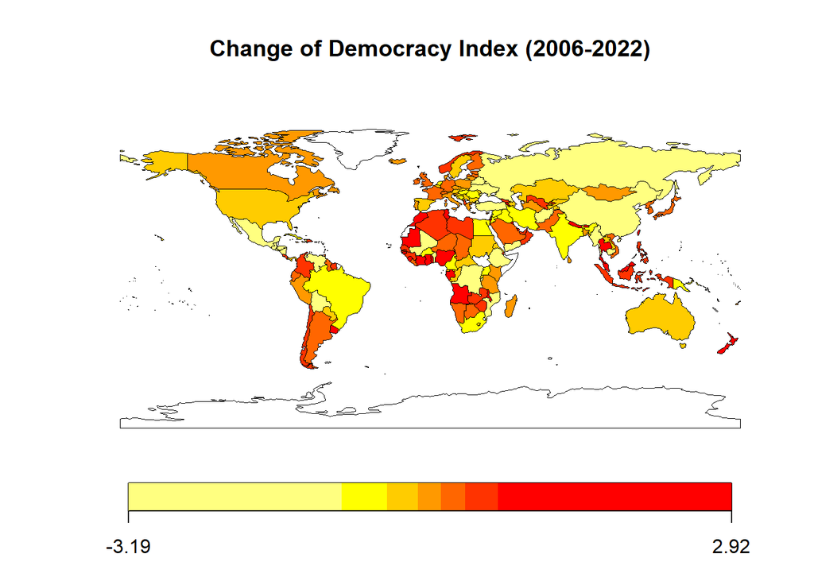

```r
mapCountryData(world_map_changes, nameColumnToPlot = "Change_in_index", mapRegion = "world", colourPalette = "heat",
               addLegend = TRUE, borderCol = "black", mapTitle = "Change of Democracy Index (2006-2022)",
               aspect = 1, missingCountryCol = NA, add = FALSE, nameColumnToHatch = "", lwd = 0.5)
```

# Q8a: Coponents of the Demography Index

```r
combined.table.GIAPLC <-merge(combined.table.GIAP,components,by="Country")
combined.table.GIAPLC %>% head(5)
```

```
##       Country UN Region IMF[5][6] IMF[5][6] World Bank[7] World Bank[7]
## 1 Afghanistan      Asia     2,456      2020         1,666          2021
## 2     Albania    Europe    19,029      2023        15,709          2021
## 3     Algeria    Africa    13,507      2023        12,128          2021
## 4      Angola    Africa     7,222      2023         6,491          2021
## 5   Argentina  Americas    27,261      2023        23,650          2021
##   CIA[8][9][10] CIA[8][9][10]   Region Count[2] Rate per 100,000 [3]
## 1         1,500          2021     Asia   28,240                   77
## 2        14,500          2021   Europe    5,112                  183
## 3        11,000          2021   Africa   94,749                  217
## 4         5,900          2021   Africa   24,966                   79
## 5        21,500          2021 Americas  114,074                  249
##   Male (%)[a] Female (%)[4] National (%)[b] Foreign (%)[5] Occupancy (%)[6]
## 1        97.4           2.6            99.1            0.9            179.9
## 2        98.0           2.0            98.1            1.9             84.7
```

[output cut: 39 more lines]

```r
ElectoralProccess <- as.numeric(combined.table.GIAPLC$`Electoral processand pluralism`)
FunctioningOfGovernment <- as.numeric(combined.table.GIAPLC$`Functioningof government`)
PoliticalParticipation <- as.numeric(combined.table.GIAPLC$`Politicalparticipation`)
PoliticalCulture <- as.numeric(combined.table.GIAPLC$`Politicalculture`)
CivilLiberties <- as.numeric(combined.table.GIAPLC$`Civilliberties`)

DemocracyComponents<-cbind(ElectoralProccess,FunctioningOfGovernment,PoliticalCulture,PoliticalParticipation,CivilLiberties)
DemocracyComponentsNames<-c("ElectoralProccess","FunctioningOfGovernment","PoliticalCulture","PoliticalParticipation","CivilLiberties")

CalcCor <- function(vec,titles){
  result<-data.frame(matrix(0,nrow=5,ncol = 5,dimnames = list(c(titles),c(titles))))
  for(i in 1:5){
    for(j in 1:5){
      result[i,j] <- cor(vec[,i],vec[,j])
    }
  }
  return(result)
}

CalcCor(DemocracyComponents,DemocracyComponentsNames)
```

```
##                         ElectoralProccess FunctioningOfGovernment
## ElectoralProccess               1.0000000               0.8359240
## FunctioningOfGovernment         0.8359240               1.0000000
## PoliticalCulture                0.4811656               0.6504473
## PoliticalParticipation          0.8034600               0.7439104
## CivilLiberties                  0.9151837               0.8719030
##                         PoliticalCulture PoliticalParticipation CivilLiberties
## ElectoralProccess              0.4811656              0.8034600      0.9151837
## FunctioningOfGovernment        0.6504473              0.7439104      0.8719030
## PoliticalCulture               1.0000000              0.5172481      0.5963084
## PoliticalParticipation         0.5172481              1.0000000      0.7963360
## CivilLiberties                 0.5963084              0.7963360      1.0000000
```

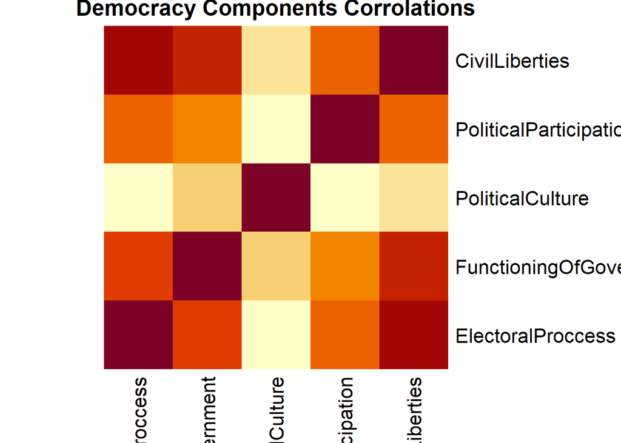

```r
heatmap(CalcCor(DemocracyComponents,DemocracyComponentsNames)%>%as.matrix(),
        Rowv = NA,      # Disable row clustering
        Colv = NA,      # Disable column clustering
        scale = "none", # Do not scale the values
        main = "Democracy Components Corrolations",
        colnames = DemocracyComponentsNames,
        rownames = DemocracyComponentsNames)
```

## Q8b

```r
gdp.by.ElectoralProccess<-lm(CIA_reported~ ElectoralProccess+FunctioningOfGovernment+PoliticalCulture+PoliticalParticipation+CivilLiberties)
summary(gdp.by.ElectoralProccess)
```

```
##
## Call:
## lm(formula = CIA_reported ~ ElectoralProccess + FunctioningOfGovernment +
##     PoliticalCulture + PoliticalParticipation + CivilLiberties)
##
## Residuals:
##    Min     1Q Median     3Q    Max
## -31126  -8533  -2201   6792  67664
##
## Coefficients:
##                         Estimate Std. Error t value Pr(>|t|)
## (Intercept)             -18252.1     4978.8  -3.666 0.000353 ***
## ElectoralProccess        -2447.6      974.9  -2.510 0.013237 *
## FunctioningOfGovernment   4671.4     1130.1   4.134 6.23e-05 ***
## PoliticalCulture          2951.8      972.4   3.036 0.002880 **
## PoliticalParticipation     722.8     1193.0   0.606 0.545640
## CivilLiberties            2094.5     1433.3   1.461 0.146261
## ---
## Signif. codes:  0 '***' 0.001 '**' 0.01 '*' 0.05 '.' 0.1 ' ' 1
##
## Residual standard error: 16070 on 135 degrees of freedom
## Multiple R-squared:  0.5085, Adjusted R-squared:  0.4902
## F-statistic: 27.93 on 5 and 135 DF,  p-value: < 2.2e-16
```

```r
coefficients <- coef(summary(gdp.by.ElectoralProccess))[, "Estimate"]
p_values <- coef(summary(gdp.by.ElectoralProccess))[, "Pr(>|t|)"]
significance_level <- 0.01

significant_coefficients <- coefficients[p_values < significance_level]
significant_coefficients
```

```
##             (Intercept) FunctioningOfGovernment        PoliticalCulture
##              -18252.095                4671.371                2951.824
```

```r
residuals <- rstudent(gdp.by.ElectoralProccess)
# Compute the 99th percentile of the residuals
percentile_99 <- quantile(residuals, 1-significance_level)
# Find the values in residuals that are bigger or smaller than the 99th percentile
outliers <- residuals[residuals > percentile_99 | residuals < -percentile_99]
outlier_countries <- combined.table.GIAPLC$Country[which(residuals>percentile_99 | residuals< -percentile_99)]
outlier_countries
```

```
## [1] "Luxembourg" "Qatar"
```

```r
residuals_table <- data.frame(Country = combined.table.GIAPLC$Country, Residuals = residuals)

top_outliers <- head(residuals_table[order(residuals_table$Residuals, decreasing = TRUE), ], 5)

bottom_outliers <- head(residuals_table[order(residuals_table$Residuals), ], 5)

outliers_table <- rbind(top_outliers, bottom_outliers)

#Other factors that may contribute to a country's GDP score is being part of an alliance,
# Such as NATO, or the UN. In addition, amount of natural resources the country have.



outliers_table
```

```
##        Country Residuals
## 110      Qatar  4.583955
## 79  Luxembourg  4.458022
## 116  Singapore  4.099894
## 62     Ireland  3.470664
## 10     Bahrain  2.372499
## 14       Benin -2.017805
## 135    Uruguay -1.662774
## 65     Jamaica -1.533157
## 86   Mauritius -1.514043
## 58       India -1.512699
```